Volver al inicio

# Unidad 4. Estructura y estética de gráficos con ggplot2.

En esta unidad veremos una serie de contenidos relacionados con parámetros estructurales del gráfico (como las escalas, la división de la ventana gráfica, etc.) y estéticos que van desde la paleta de colores utilizada hasta el tema general.

Sin embargo, empezaremos viendo cómo exportar un gráfico para luego poder ir extrayendo los que iremos generando.

## Exportación de resultados y gráficos

### Exportación de datos

A este respecto, en mi práctica personal suelo leer los resultados desde la consola de R y, de ser necesario, realizo el pasaje manualmente de la información que me resulte de interés a un excel para su almacenamiento. De todas maneras, existen maneras de exportar diferentes formatos de archivos desde R. Cuando lo considero necesario, utilizo archivos del tipo csv. Así por ejemplo para exportar los datos de una regresión:

```r
REG <- summary(fit1) # creamos un objeto para poder después extraer los coeficientes

write.csv2(REG$coefficients, "regresión prueba.csv")
```

Como vemos, debo tener una tabla limpia y luego agregar el nombre y formato del archivo a crear. Lo mismo si quisiera extraer la tabla de un anova o un tukey:

```r
write.csv2(anova(fit3), "anova prueba.csv")
write.csv2(tukey3$groups, "tukey prueba2.csv")
```

Por supuesto, todo lo que exportemos se guardará en el directorio seteado al comienzo con setwd().

### Exportación de gráficos

Este apartado es mucho más útil que el anterior y nos va a permitir extraer nuestras figuras que hayamos creado de una forma adecuada. Veremos 3 formas de exportar un gráfico.

#### Interfaz gráfica de RStudio

En la ventana 4 de RStudio se nos muestran los gráficos que hayamos generado. En la barra superior de esa ventana (siempre que estemos en la pestaña *Plots*) veremos la opción de *Export*. Si allí entramos en *Save as image* nos brinda una serie de opciones de exportación. Menciono esta posibilidad porque en algunos contextos puede sernos de utilidad. Como siempre que utilizamos la interfaz gráfica, esta tiene la desventaja de no nos deja ningún tipo de registro de lo que hayamos hecho, lo que no nos permite repetir la exportación en igualdad de condiciones, si es que fuera necesario.

#### Devices

Una segunda opción es el uso de Devices. Esta opción consiste en un código inicial donde definimos el formato, luego el gráfico y finalmente el cierre. Así por ejemplo para exportar un jpg:

```r
jpeg(file = "mi_grafico.jpg",
      width = 12, height = 10, #ancho y alto
     quality = 95, #grado de no-compresión
     res = 300) #resolución en puntos por pulgada
boxplot(PS~ET,
        data = SEM_Alim) # comandos gráficos
dev.off() # cerrar el gráfico
```

También es posible exportar en PDF, SVG (formato vectorizado), y otros. Es recomendable pintar todo el texto (inicio + gráfico + cierre) y luego ejecutar todo como una única corrida.

#### ggsave

Esta es una opción interna dentro del entorno de **ggplot2**. Se debe ejecutar a continuación y luego de haber corrido el gráfico. Su estructura es la siguiente:

```r
ggsave("mi gráfico.png", # nombre y formato
       width = NA, height = NA, # ancho y alto, si no especificamos se ve tal cual en la ventana 4
       dpi = 300) # resolución
```

Si se quiere exportar en formato SVG, es necesaria la instalación del paquete *svglite*.

## Títulos

Para modificar los títulos de nuestros gráficos utilizaremos el parámetro *labs*. Allí modificaremos la etiqueta de cada eje, de la leyenda, y posibles títulos del gráfico.

```r
G3 <- G3 +
  labs(x = "Estrés térmico",
       y = "Peso seco (g)",
       fill = expression(CO[2]), # cambia la leyenda
       title = "Peso seco de semillas de soja") ; G3
```

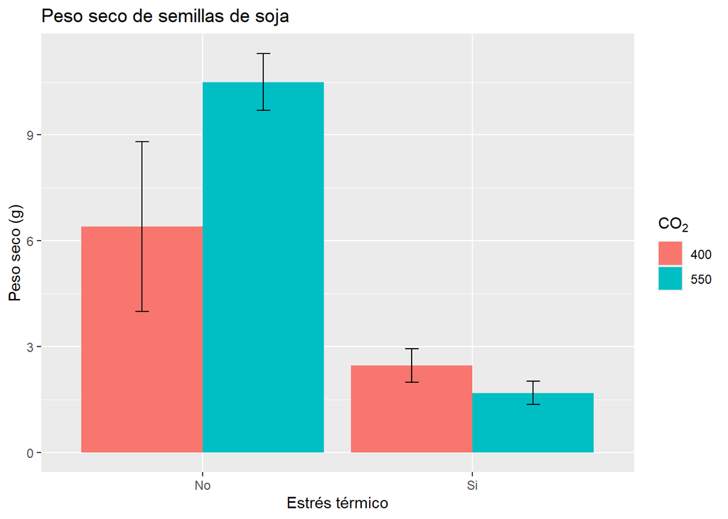

## Scales

### Manipulando los ejes

Podemos establecer la estructura de nuestros ejes a partir de los comandos `scale_x_***` donde en debemos indicar el tipo de dato de nuestro eje (todo esto es válido tanto para el eje *x* como el *y*). Así dependiendo del tipo de variable, serán los datos a modificar. Por ejemplo si la variable es continua:

```r
  ... +
  scale_x_continuos(expand = c(0,0), # estable la ubicación en el eje
                    limits=c(inferior,superior), # entre qué valores se graficará
                    breaks = seq(inferior,superior, # entre qué valores se mostrará la escala
                                 by = número)) # cada cuánto habrá cortes
```

Es importante destacar que el parámetro *limits* establece los límites del gráfico y los valores que se tomarán en cuenta. Si algo de nuestros datos excede ese valor, no será considerado para el gráfico. Si en cambio queremos tomar en cuenta todos los datos pero hacer un recorte en el gráfico, debemos usar el comando `coord_cartesian(ylim=c(inferior,superior))` en una nueva línea.

En el caso de querer modificar los nombres que aparecen en el eje (habitualmente para variables discretas o categóricas) usaremos el comando `labels`:

```r
scale_x_discrete(labels = c(etiqueta1, etiqueta2, ...))
```

Continuando con nuestro ejemplo en el G3, comparemos con y sin manipulación de ejes:

```r
G3
G3 <- G3 + scale_x_discrete(labels = c("Sin ET", "Con ET")) +
  scale_y_continuous(expand = c(0,0),
                     limits = c(0, 12),
                     breaks = seq(0,12, by= 1)); G3
```

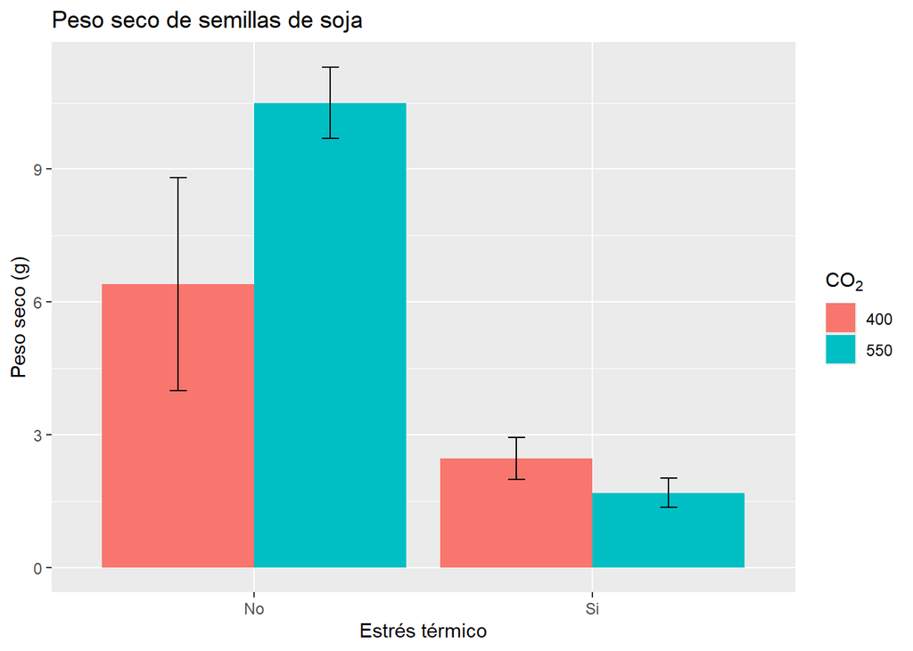

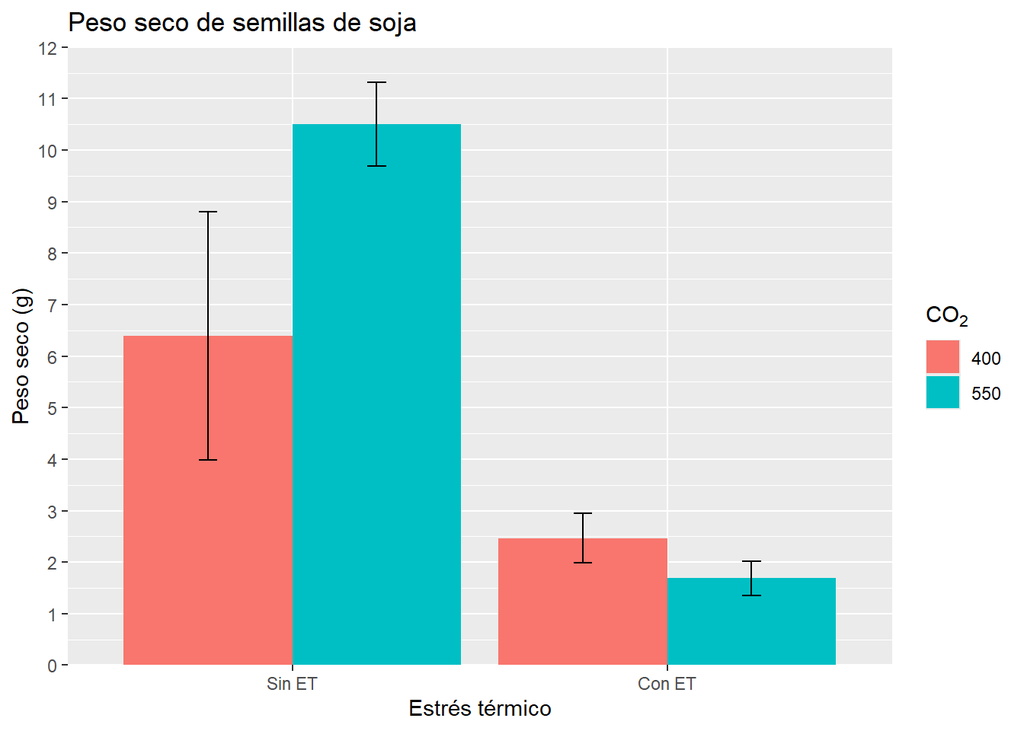

### Colores

R permite la utilización de una gran cantidad de colores diferentes (ver documento *ColorChart*). Se pueden modificar los colores de casi todos los objetos en un gráfico, aquí nos centraremos en contornos y rellenos de nuestros elementos que representan los datos. Como regla general, si nuestro geom admite relleno este se modifica con el parámetro *fill*, mientras que *col* modificará el borde. Si no se admite relleno (gráficos de líneas o puntos), solo utilizaremos *col*. Cómo modificamos los colores varía un poco según diferentes casos:

- Si el color es el mismo para todos, se modifica dentro de los parámetros del geom. Por ejemplo: `geom_col(col= "black", fill= "red")`.
- Si debemos modificar el color o el relleno según un criterio de clasificación (es decir que seteamos el parámetro que clasifica en el aes()) usaremos el comando `scale_colour_manual(values=c("color1", "color2", ....))` para establecer manualmente los colores. Lo mismo para el relleno pero será `scale_fill_manual(values=c("color1", "color2", ....))`. Es importante destacar que la cantidad de colores debe coincidir con los niveles del factor en cuestión.

Veamos un ejemplo donde combinamos lo visto hasta ahora:

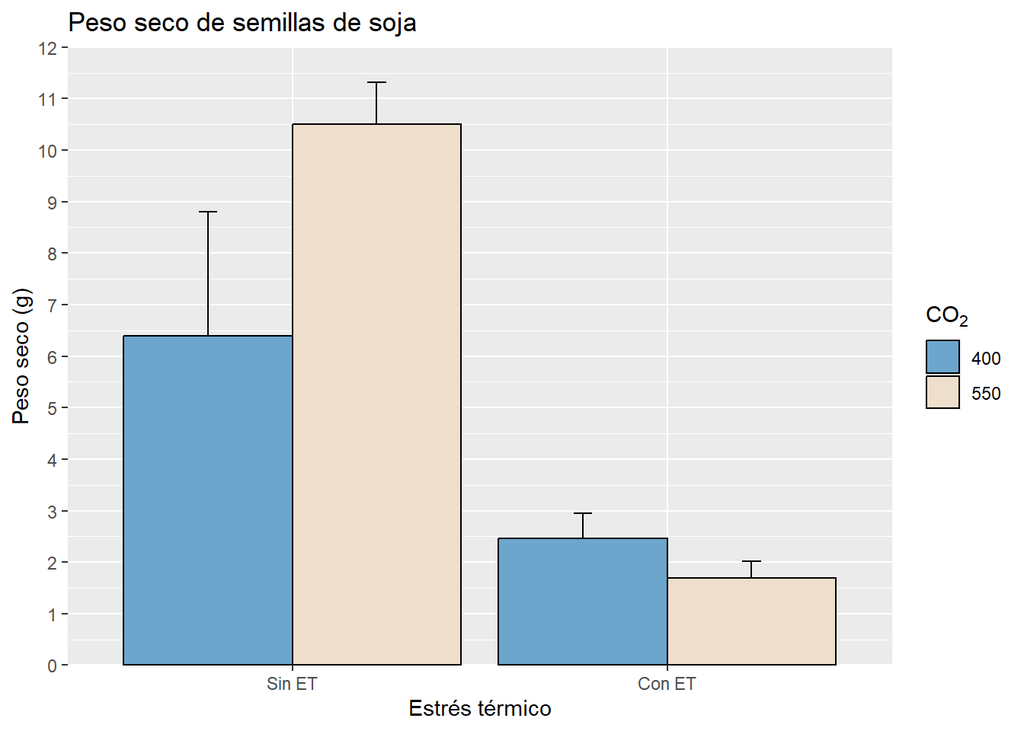

```r
G3 + geom_col(col = "black", position = "dodge") + # repetimos para cambiar el borde
  scale_fill_manual(values = c("skyblue3", "antiquewhite2"))
```

En estos casos decidimos establecer manualmente el color. También podemos utilizar paletas de colores que vienen preestablecidas. Algunas están con el R base y otras debemos cargarlas con paquetes. En este taller veremos el uso de la paleta **viridis**, de paquete homónimo. La función que utilizaremos es `scale_fill_viridis_d()`, donde la “d” refiere a discreto. Esta escala está especialmente diseñada para que la puedan distinguir personas daltónicas y asignará tantos colores como sean necesarios. La escala viridis va del violeta al amarillo, podemos reducir la escala estableciendo el comienzo y el final de la misma. Por otro lado, también veremos el uso del paquete *paletteer*, que incluye una enorme cantidad de paletas para utilizar (https://r-charts.com/es/paletas-colores/). Por ejemplo en el gráfico anterior:

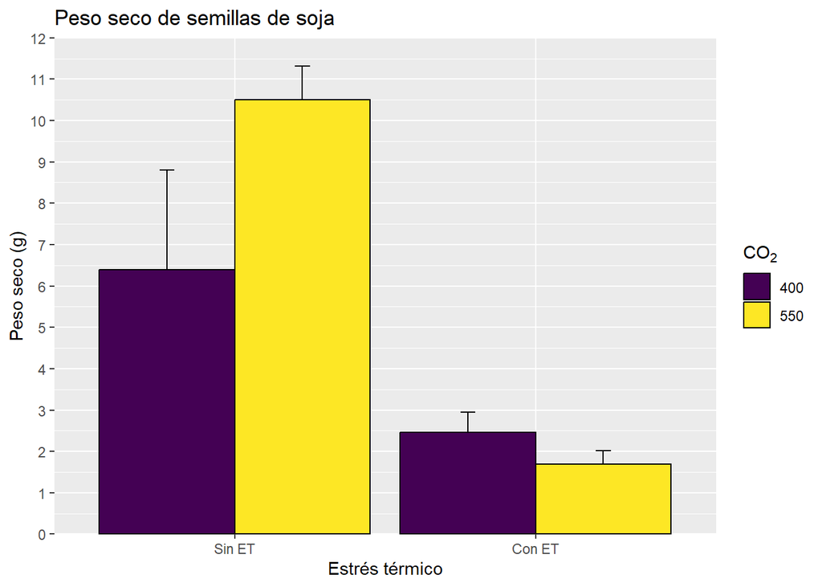

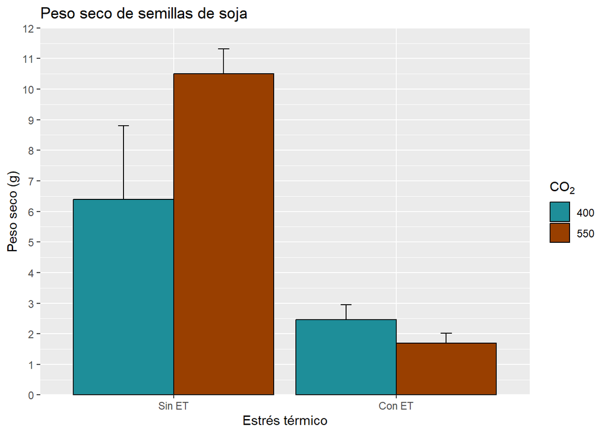

```r
G3 + geom_col(col = "black", position = "dodge") +
  scale_fill_viridis_d()

library(paletteer)
G3 + geom_col(col = "black", position = "dodge") +
  scale_fill_manual(values = paletteer_d("colorBlindness::Blue2DarkOrange12Steps", 2,
                                         type = "continuous"))
```

Si queremos saber exactamente qué colores utilizó la función, podemos utilizar la función `viridis` para nombrar los colores:

```r
library(viridis)
viridis(2)
```

```
## [1] "#440154FF" "#FDE725FF"
```

```r
paletteer_d("colorBlindness::Blue2DarkOrange12Steps", 2,
                                         type = "continuous")
```

```
## <colors>
## #1E8E99FF #993F00FF
```

Nos los da con el código RGB que podemos utilizar para otros gráficos.

### Forma y tipo de línea

Otro parámetro que puede generar diferencias entre los niveles de una factor o que puede ser modificado para todos nuestros valores es la forma. Para indicar el cambio se hará del mismo modo que para el color o relleno, pero con el parámetro `shape`. Las diferentes formas se pueden visualizar en el documento Refcard, son 25 y algunas permiten que se les modifique el relleno. La forma puede ser combinada por el color para enfatizar las diferencias, y originarán una sola leyenda, por ejemplo:

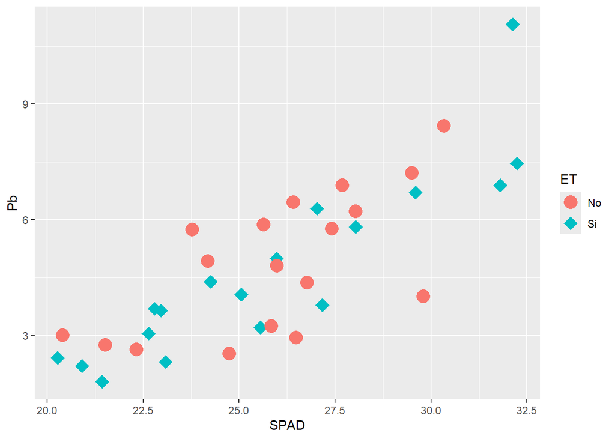

```r
ggplot(HOJA,
       aes(SPAD, Pb,
           col = ET,  # clasificamos por color
           shape = ET)) + # y por forma
  geom_point(size= 5) +
  scale_shape_manual(values = c(16, 18))
```

A su vez podemos establecer tipos de líneas en un gráfico de líneas. Funciona de la misma manera con el parámetro `linetype`:

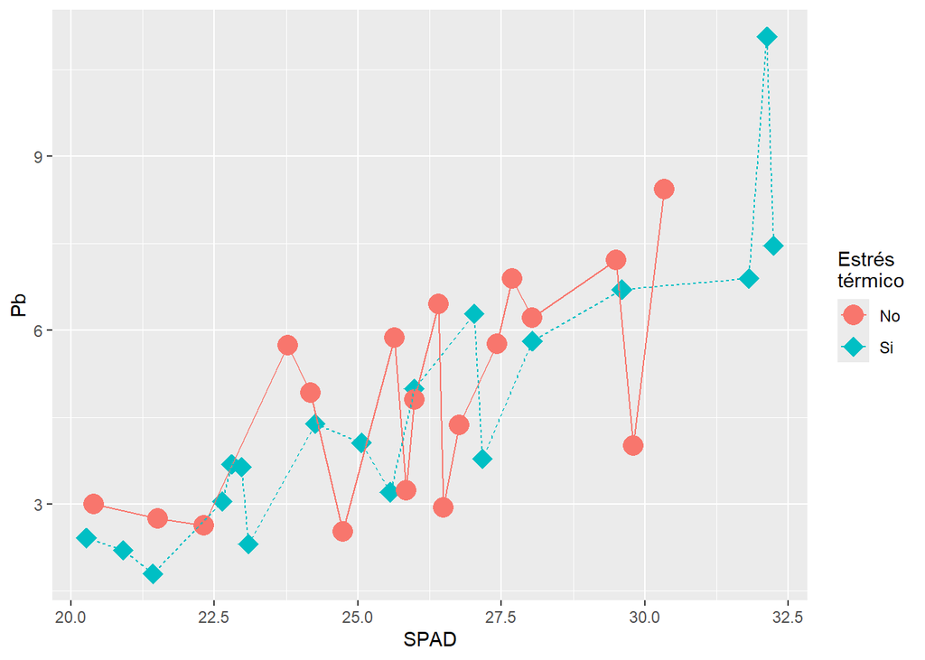

```r
ggplot(HOJA,
       aes(SPAD, Pb,
           col = ET,
           shape = ET,
           linetype = ET)) +
  geom_point(size= 5) +
  geom_line()+
  scale_shape_manual(values = c(16, 18)) +
  labs(col = "Estrés \ntérmico",
       shape = "Estrés \ntérmico",
       linetype = "Estrés \ntérmico")
```

Como vemos, como todos los parámetros de clasificación responden al mismo factor, la leyenda es una sola. Para modificar el título de la leyenda se debe indicar el cambio para todos los parámetros involucrados.

También se puede clasificar por tamaño en el caso de una variable continua, generará una escala automática.

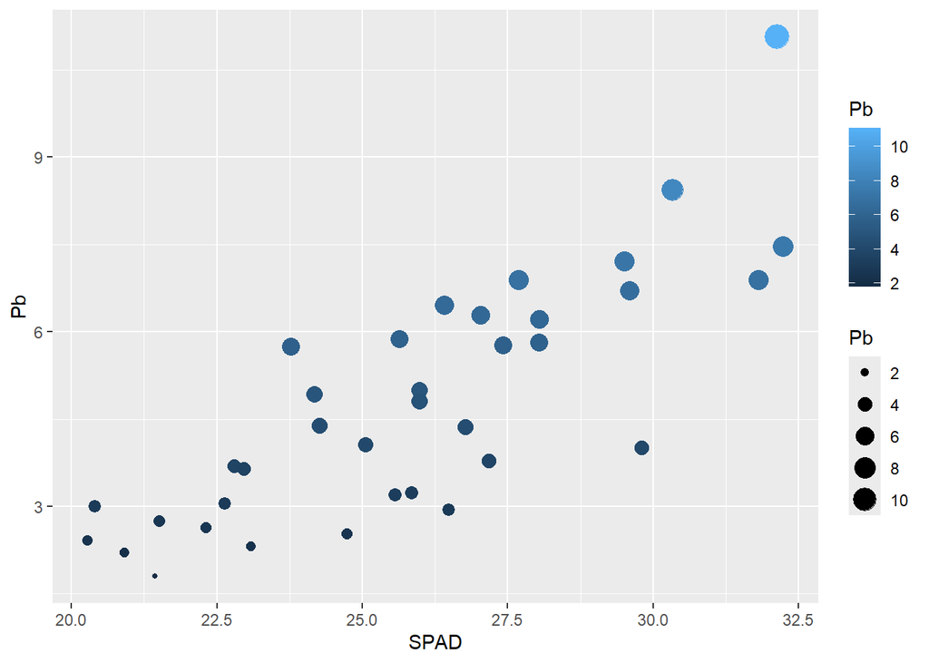

```r
ggplot(HOJA,
       aes(SPAD, Pb,
           size = Pb, # genera una escala discreta de tamaños
           col = Pb)) + # genera una escala continua de color
  geom_point()
```

## Subdivisión del gráfico con faceting

Si nuestro gráfico requiere la subdivisión por varios factores, además de por colores podemos dividir la ventana con faceting. El parámetro facet_grid requiere que introduzcamos por cuál/es variable/s se dividirá, por lo tanto toma la forma var1~var2, si solo hay una se reemplaza la faltante por un punto (.). Es importante destacar que todas las divisiones responderán a la misma escala. Así por ejemplo:

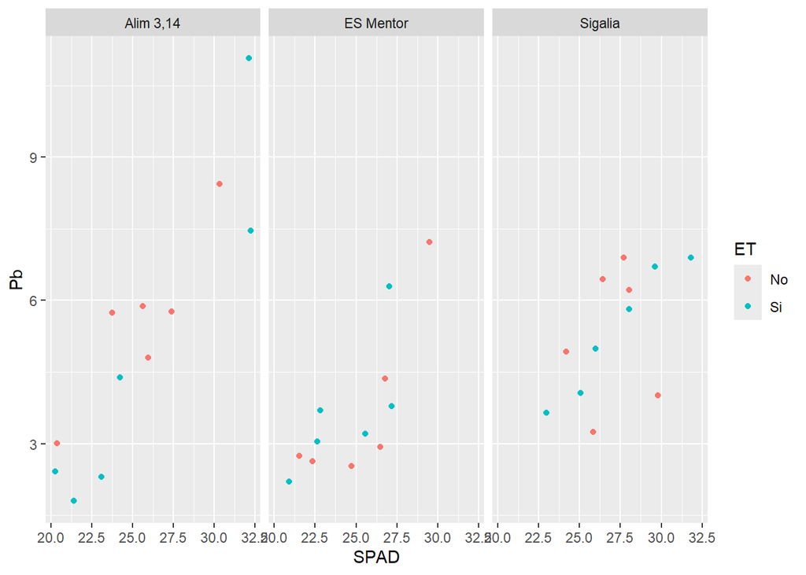

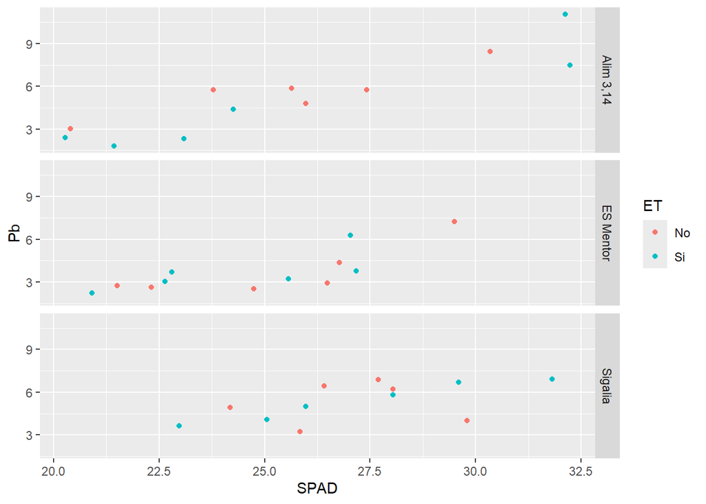

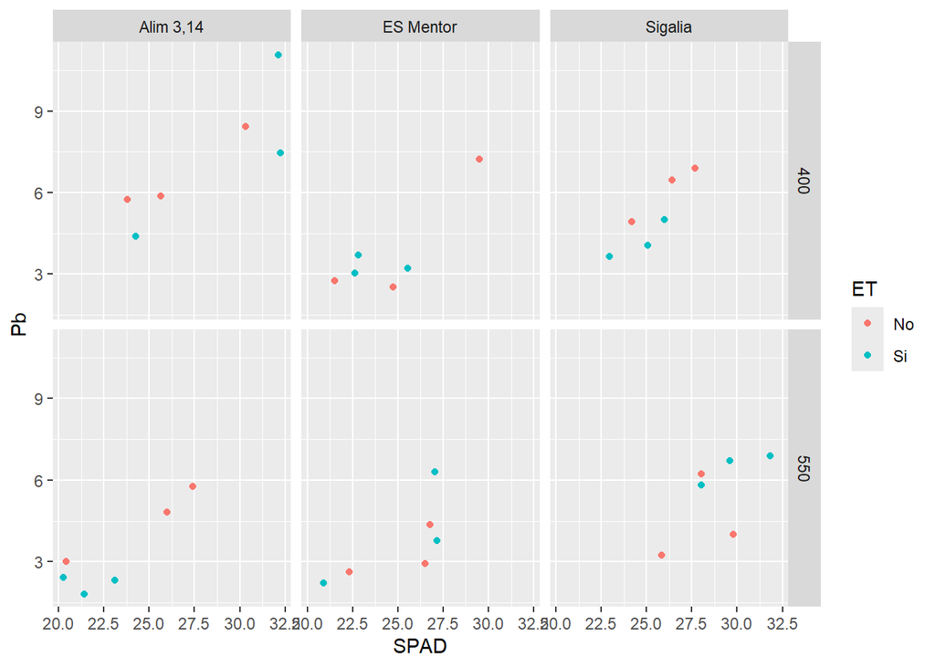

```r
G2 + facet_grid(.~GT) # para dividir verticalmente
G2 + facet_grid(GT~.) # para dividir horizontalmente
G2 + facet_grid(CO2~GT) # para dividir por ambas
```

### Multifaceting

Si quisiéramos definir más de un nivel de división, podemos utilizar la función `facet_nested` del paquete *ggh4x*. Por ejemplo de la siguiente manera:

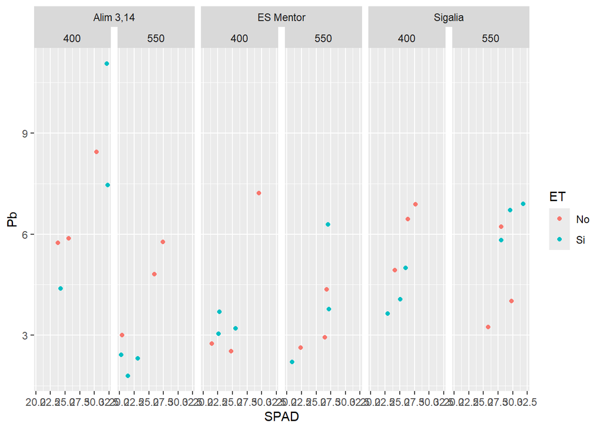

```r
library(ggh4x)
G2 + facet_nested(.~GT+CO2) # cada nivel de GT se divide por CO2
```

## Definiendo la estética de nuestros gráficos

### Exportación y edición posterior: un arma de doble filo

La posibilidad de exportar un gráfico y editarlo posteriormente en otro software siempre está sobre la mesa. Este apartado tiene como idea presentar y analizar brevemente sus ventajas y desventajas.

En este caso la que más he utilizado y funciona muy bien es el uso de imágenes vectorizadas. Si exportamos un archivo en formato svg, el mismo podrá verse en esta forma en software de edición de imagen. El que yo recomiendo es Inkscape, ya que es gratuito y multiplataforma y su forma de uso es muy intuitivo. La ventaja de tener la imagen vectorizada es que no perdemos calidad y además nos brinda la posibilidad de manipular cada uno de los elementos del gráfico individualmente.

El manejo externo de los gráficos es una herramienta muy poderosa en cuanto a las posibilidades que nos ofrece, ya que podemos modificar lo que queramos a nuestro antojo y con muy buenos resultados. Sin embargo, tiene una desventaja enorme: nuestra edición no es repetible. Esto quiere decir, que si por algún motivo tuvimos que hacer el gráfico de nuevo, todo el trabajo de edición empieza de cero. Y, al menos en mi experiencia de trabajo, rehacer un gráfico ya hecho es cosa de todos los días (decidimos incluir o no un outlier, corregimos datos, modificamos un factor, cambiamos de idioma el gráfico, etc.).

Por estos motivos, mi recomendación es intentar hacer lo más posible directamente en R y solo en casos de extrema necesidad acudir al software externo. A pesar de esto, no deja de ser una herramienta potente y a tener en cuenta.

### Definiendo el `theme` en ggplot2

Cuando realizamos un gráfico con `ggplot` la mayor parte de las cuestiones estéticas se definen dentro del parámetro `theme`. Este apartado nos permite modificar las letras del gráficos en general, de los ejes, de los títulos de los ejes, la posición y estructura de la leyenda, etc. La estructura general consiste en nombrar el elemento a modificar, luego establecer el tipo de elemento, y finalmente modificar los parámetros. Supongamos a modo de ejemplo que queremos que las etiquetas del eje *x* estén en negro, con tamaño de letra 12, con inclinación vertical. Entonces escribiremos:

```r
Gráfico +
  theme(axis.text.x = element_text(size=12 ,
                                   colour = "black",
                                   angle= 90))
```

Podemos ir separando por comas diferentes elementos que queramos modificar. Otra opción interesante es crear un objeto con todas nuestras modificaciones, que luego podemos aplicar a todos nuestros gráficos. También existen temas prediseñados que modifican varios parámetros a la vez. Estos se introducen con el comando theme_ donde las opciones son muchas, en particular a mí me gusta la opción `theme_pubr` [^1] del paquete *ggpubr*. Podemos combinar todo en un objeto, por ejemplo:

```r
library(ggpubr)
```

```r
THEME <-theme_pubr() +
theme(plot.caption = element_text(hjust = 0, vjust=.5),
               plot.title.position = "plot",
               plot.title = element_text(size=rel(1.5)),
               text = element_text(size=12, colour = "black"),
               axis.text = element_text(size=12 , colour = "black"),
               axis.line = element_line(colour = "black"),
               legend.position = "right",
               legend.text = element_text(size=12, colour = "black"),
               legend.background = element_rect(colour = "black")) # recuadro de la leyenda
```

Luego podemos incorporarlo al final de los gráficos, así:

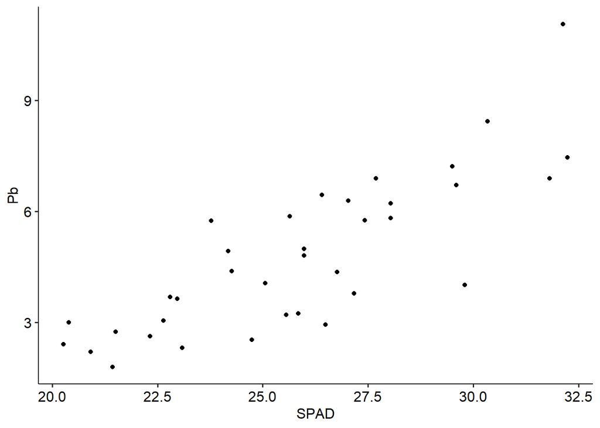

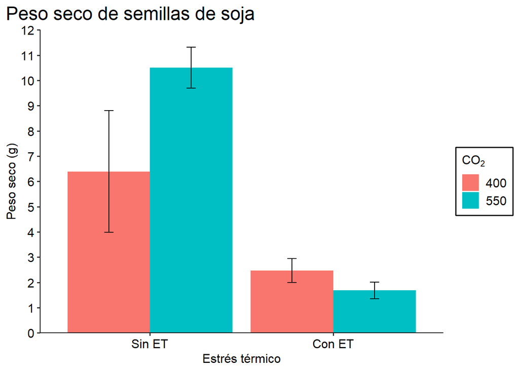

```r
G1 + THEME
G3 + THEME
```